# Monitoring and Accelerating Convergence

## Introduction

1. Monitoring Convergence using multiple MC experiments
2. Antithetic Variables

## Monitoring Convergence

As a toy example, consider the simple function \(h(x) = [cos(50x) + sine(50x)]^2\). Using a simple MC algorithm, we can estimate \(\theta = \int_0^1 h(x)\). Let us generate \(n\) samples \(x_1, ..., x_n \sim Unif(0,1)\), such that \(\displaystyle \theta = E[h(x)] \approx \frac{1}{n} \sum^n h(x_i)\).

```r
set.seed(3456)
n = 80000
x = runif(n)
h = function(x){
  v = (cos(50*x) + sin(50*x))^2
  return(v)
}

#thetaHat = mean(h(x)) # theta hat

theta_est = cumsum(h(x))/1:n ## cumulative mean

se = sqrt( cumsum((h(x) - theta_est)^2 ) / 1:n ) / sqrt(1:n)
```

## Monitoring Convergence

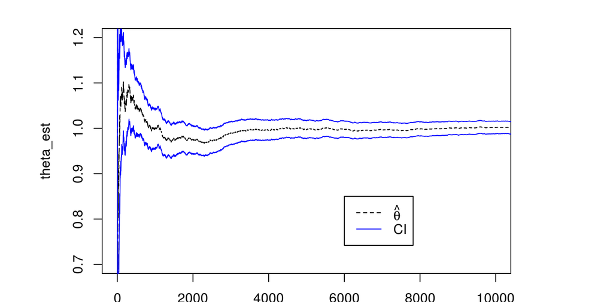

```r
par(pin = c(5,3))
plot(x = 1:n, y = theta_est, type = "l", lty=2, ylim = c(0.7, 1.2), xlim = c(0, 10000))
lines(x = 1:n, y = theta_est - 1.96*se, col = "blue")
lines(x = 1:n, y = theta_est + 1.96*se, col = "blue")
legend(x = 6000, y = 0.85, legend = c(expression(hat(theta)), "CI"),
       border = "white", col = c("black", "blue"), lty = c(2, 1))
```

## Monitoring Convergence

If we now add a new experiment, the new sample is not guaranteed to stay within the 95% CI.

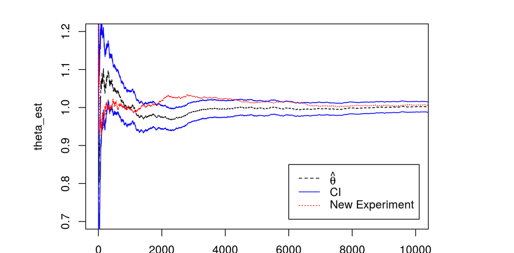

## Monitoring Convergence

Monitoring convergence of Monte Carlo samples is important to assessing the quality of estimators. For some MC estimate \(\theta_{MC}\), it is possible to run many parallel processes and graphically monitor how they converge, and from those samples obtain a confidence band.

However, this may be computationally costly, and resource (e.g. hardware + time) intensive.

To understand how much memory our experiments are using, we can use the library [`profmem`](https://cran.r-project.org/web/packages/profmem/vignettes/profmem.html). Many programming langugages have libraries for profiling code, and monitoring bottlenecks and resource consumption.

- To install: `install.packages("profmem")`

## Monitoring Convergence

While running, monitor your computer's resource manager

```r
## parallel monte carlo samples
M = 200L
X = matrix(data = runif(n*M), nrow = n, ncol = M)
h_samples = h(X)
thetaEstimates = apply(X = h_samples, MARGIN = 2, FUN = function(v){ cumsum(v)/1:n } )

parallelCI = t(apply(X = thetaEstimates, MARGIN = 1, FUN = quantile, c(0.025, 0.50, 0.975)))

summary(parallelCI)
```

```
##       2.5%              50%            97.5%
##  Min.   :0.01199   Min.   :0.886   Min.   :1.006
##  1st Qu.:0.99157   1st Qu.:1.001   1st Qu.:1.007
##  Median :0.99495   Median :1.001   Median :1.009
##  Mean   :0.99206   Mean   :1.001   Mean   :1.012
##  3rd Qu.:0.99620   3rd Qu.:1.001   3rd Qu.:1.012
##  Max.   :0.99717   Max.   :1.023   Max.   :1.993
```

```r
integrate(f = h, lower = 0, upper = 1) ## comparison
```

```
## 1.001377 with absolute error < 9.5e-11
```

## Monitoring Convergence

### Parallel CI

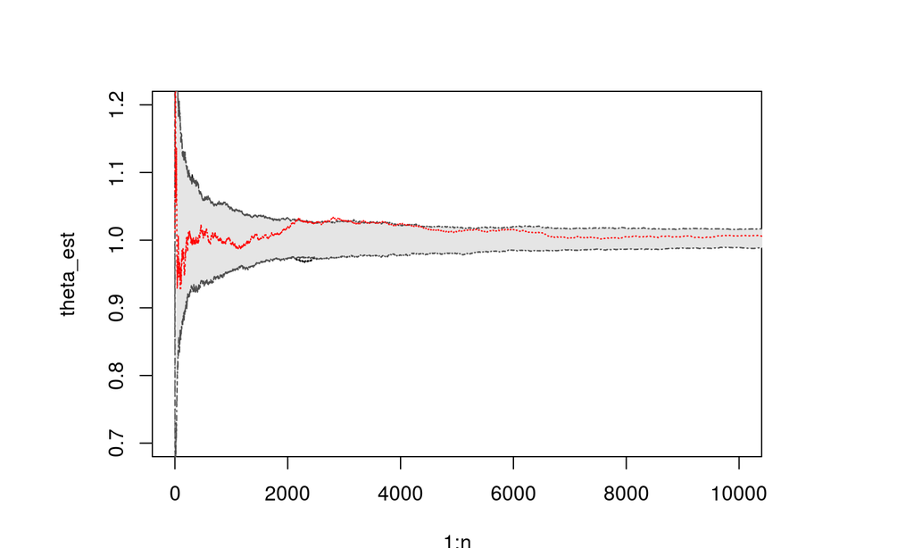

## Monitoring Convergence

An approximate but cheaper version of this basic Monte Carlo estimate of the variability is to bootstrap the originally obtained samples and from there estimate a 95% confidence band.

```r
## bootstrap
M = 200L
ind = sample(x = 1:n, size = n*M, replace = TRUE) ## sample indices
boot_samples = matrix(data = h(x[ind]), nrow = n, ncol = M) ## matrix of samples
boot_est = apply(X = boot_samples, MARGIN = 2, FUN = cumsum) / 1:n ## matrix

bootCI = t(apply(X = boot_est, MARGIN = 1, FUN = quantile, c(0.025, 0.50, 0.975)))
summary(bootCI)
```

```
##       2.5%                50%             97.5%
##  Min.   :0.0005169   Min.   :0.9503   Min.   :1.008
##  1st Qu.:0.9928645   1st Qu.:1.0031   1st Qu.:1.009
##  Median :0.9956523   Median :1.0032   Median :1.010
##  Mean   :0.9934111   Mean   :1.0033   Mean   :1.013
##  3rd Qu.:0.9978689   3rd Qu.:1.0034   3rd Qu.:1.013
##  Max.   :0.9989545   Max.   :1.0083   Max.   :1.994
```

## Monitoring Convergence

### Bootstrap CI

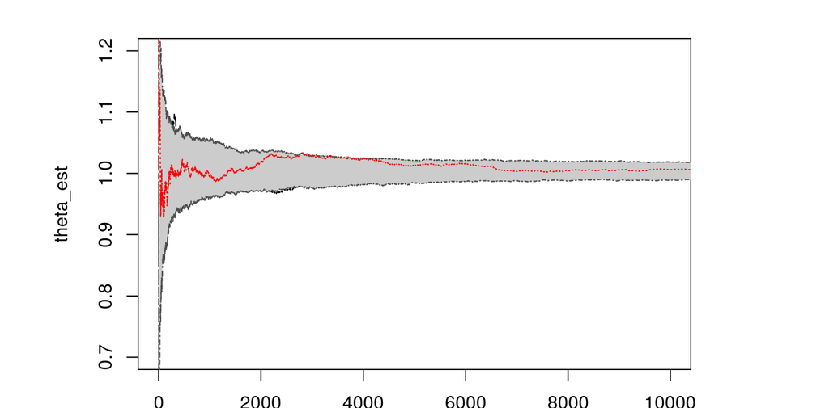

## Antithetic Variables

In previous experiments, when we've worked to generate pseudo-random samples from distributions, we've worked with *iid* (independent and identically distributed) peuso-random samples from an instrumental distribution.

Generally, *iid* samples are always preferable, but not always cost efficient. As problems become more complicated, generating random samples from a target distribution will become more cumbersome and time/resource consuming.

Therefore, in this section we will present methods in which we can double down on our generated samples to speed up convergence and utilize more of our available resources.

## Antithetic Variables

Suppose we are interested in estimating a parameter \(\theta\) and we have two unbiased estimators \(X\) and \(Y\) with finite variances \(\sigma^2_X = \sigma^2_Y = \sigma^2\). The average of the two unbiased estimators is also an unbiased estimator, \(Z = (X + Y) / 2\). Given \(X, Y\) and \(Z\) are all unbiased, we can compare them using their variances and choose the smallest of the three.

The variance for \(Z\) is given by \[ \begin{aligned} Var(Z) & = Var(\frac{X + Y}{2}) = \left(\frac{1}{2} \right)^2 \times Var(X + Y) \\ \ & = \frac{1}{4} \left( Var(X) + Var(Y) + 2 Cov(X, Y) \right) \\ \ & = \frac{1}{4} Var(X) + \frac{1}{4} Var(Y) + \frac{1}{2} Cov(X, Y) \\ \ & = \frac{1}{4} \sigma^2 + \frac{1}{4} \sigma^2 + \frac{1}{2} Cov(X, Y) \\ \ & = \frac{1}{2} (\sigma^2 + Cov(X, Y)) \end{aligned} \]

If \(Cov(X, Y) < 0\) (or \(Cor(X, Y) < 0\)), then \(Var(Z) < \sigma^2\), therefore, \(Z\) would perform better as an unbiased estimator. In this scenario, \(X\) and \(Y\) would be *antithetic* to each other; thus they are *antithetic variables*.

## Antithetic Variables

The Monte Carlo integration estimator \[ \begin{aligned} \theta & = \displaystyle \int_{- \infty}^{\infty} h(x) f(x) dx \\ \end{aligned} \] Let \(X\) and \(Y\) denote random samples, \(x_1, ..., x_n\) and \(y_1, ..., y_n\), respectively. If \(X\) and \(Y\) are negatively correlated, then the estimator \(\hat{\theta}\) of \(\theta\) \[ \begin{aligned} \hat{\theta} & = \displaystyle \frac{1}{2n} \sum_{i = 1}^{n} [h(x_i) + h(y_i)] \\ \end{aligned} \] is more efficient than the estimator \(\displaystyle \hat{\theta} = \frac{1}{2n} \sum_{i = 1}^{2n} h(x_i)\). The random variables \(X\) and \(Y\) are then called *antithetic variables*.

## Antithetic Variables

Albeit useful, this method is not always possible. For arbitrary transformations \(h(.)\), it is not always possible to generate negatively correlations \(X\) and \(Y\).

Consider the following. Let \(h(x) = e^x\), where we'd like to solve \(\int_0^1 h(x) dx\). We can take this problem as

\[ \theta = \int_0^1 h(x) dx = \int_0^1 h(x) f(x) dx \] where \(f(x) = 1\) for a \(Unif(0,1)\) distribution. Then

## Antithetic Variables

```r
n = 50000
u = runif(n)

h = function(x){exp(x)}

thetaHat = mean(h(u))
thetaHat
```

```
## [1] 1.719875
```

```r
integrate(f = h, lower = 0, upper = 1)
```

```
## 1.718282 with absolute error < 1.9e-14
```

## Antithetic Variables

```r
u1 = runif(n/2)
u2 = 1 - u1
h = function(x){exp(x)}

thetaHatAV = mean(c(h(u1), h(u2)))
thetaHatAV
```

```
## [1] 1.718037
```

```r
cor(x = h(u1), y = h(u2)) ## correlation nearly -1
```

```
## [1] -0.9675633
```

## Exercise

Suppose \(X \sim N(0,1)\) and we wish to estimate \(\theta = E[h(X)]\) where \(h(X) = \frac{x}{(2^x - 1)}\).

By regular Monte Carlo estimation, we can estimate \(\theta\) with \(n = 10^6\) samples from \(N(0,1)\).

Compare your results with regular MC estimation.

## Appendix

## Solution to Exercise

```r
n = 10^6
m = n/2

h <- function(x){ x/(2^x - 1) }

y = rnorm(n)
theta_MC = mean(h(y))

w = rnorm(m)
theta_AS = sum(h(w) + h(-1 * w)) / n

print(theta_MC)
```

```
## [1] 1.498056
```

```r
print(theta_AS)
```

```
## [1] 1.499157
```

## Solution to Exercise

```r
## standard errors
rho = cor(h(w),h(-w))
se.a = (1+rho)*var(h(w))/n

print(rho)
```

```
## [1] -0.9524097
```

```r
print(se.a)
```

```
## [1] 1.219771e-08
```